# Aging Analysis of Mck-TSC1

Dave Bridges, Kaleigh Fisher and Binbin Lu

February 9, 2015

# Data Entry

These data are accumulated from the database. The analysis includes all alive animals, animals which were sacrificed and animals which died of natural causes (denoted in the database as “Unknown”). Animals which died with an estimated death date are excluded from the analysis. We are testing the effects of age on death by natural causes. This script is located in /Users/davebrid/Documents/GitHub/DrosophilaMuscleFunction/Lifespan and was most recently run on Sun Jan 22 15:02:35 2017.

# Mck-TSC1 Mice

```
## [1] 292
```

## Analysis

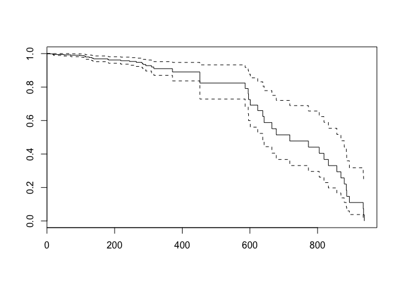

This analysis contains a total of **625** animals, from which we have detected **49** natural deaths. See Table below for a summary of natural deaths and see the figure below for the combined death curves with errors.

## Comparing all Four Genotypes

This analysis looks at all four genotypes for *Ckmm-Tsc1*.

[output not shown]

The chi-squared test for comparing all four genotypes is significant, with a p-value of 0. The results of these tests are in the table below. The effects of each genotype, relative to the knockout strains are in Table . These data are visualised in the figure. This means that the knockout mice are 3.667 to 5.347 times more likely to die at any given time, depending on the strain.

Muscle TSC1 Knockout Tests

|  | test | df | pvalue |
| --- | --- | --- | --- |
| Likelihood ratio test | 19 | 3 | 0.000322 |
| Wald test | 18 | 3 | 0.000348 |
| Score (logrank) test | 21 | 3 | 0.000088 |

Muscle TSC1 Knockout Coefficients, relative to Knockout

|  | beta | se | 2.5 % | 97.5 % | p |
| --- | --- | --- | --- | --- | --- |
| Genotype+/+; +/+ | -1.68 | 0.187 | -2.65 | -0.705 | 0.000719 |
| Genotype+/+; Tg/+ | -1.46 | 0.232 | -2.48 | -0.440 | 0.004996 |
| Genotypefl/fl; +/+ | -1.30 | 0.273 | -2.04 | -0.561 | 0.000565 |

# Comparing Floxed to Knockout

This section only compares fl/fl;+/+ to fl/fl;Tg/+.

The chi-squared test for comparing the two genotypes is significant, with a p-value of 0.002. The results of these tests are in the table below. The effects of each genotype, relative to the knockout strains are in the table below. These results are presented graphically in the figure below. This means that the knockout mice are 3.277 times more likely to die at any given time.

Muscle TSC1 Knockout Tests (WT vs KO)

|  | test | df | pvalue |
| --- | --- | --- | --- |
| Likelihood ratio test | 10 | 1 | 0.0015 |
| Wald test | 9 | 1 | 0.0026 |
| Score (logrank) test | 10 | 1 | 0.0015 |

Muscle TSC1 Knockout Coefficients, relative to Knockout

|  | beta | se | 2.5 % | 97.5 % | p |
| --- | --- | --- | --- | --- | --- |
| Genotypefl/fl; +/+ | -1.19 | 0.305 | -1.96 | -0.415 | 0.0026 |

# Comparing Control Strains

The chi-squared test for comparing the three control genotypes is not significant, with a p-value of 0.772.

# Death Logs

This table shows the age, and at risk individuals for each natural death, along with the % survival and the confidence intervals.

| time | n.risk | n.event | n.censor | surv | std.err | upper | lower | strata |
| --- | --- | --- | --- | --- | --- | --- | --- | --- |
| 10 | 188 | 1 | 0 | 0.995 | 0.005 | 1.000 | 0.984 | Genotype=fl/fl; Tg/+ |
| 17 | 187 | 0 | 3 | 0.995 | 0.005 | 1.000 | 0.984 | Genotype=fl/fl; Tg/+ |
| 18 | 184 | 1 | 7 | 0.989 | 0.008 | 1.000 | 0.975 | Genotype=fl/fl; Tg/+ |
| 19 | 176 | 0 | 1 | 0.989 | 0.008 | 1.000 | 0.975 | Genotype=fl/fl; Tg/+ |
| 21 | 175 | 0 | 3 | 0.989 | 0.008 | 1.000 | 0.975 | Genotype=fl/fl; Tg/+ |
| 22 | 172 | 0 | 1 | 0.989 | 0.008 | 1.000 | 0.975 | Genotype=fl/fl; Tg/+ |
| 28 | 171 | 0 | 2 | 0.989 | 0.008 | 1.000 | 0.975 | Genotype=fl/fl; Tg/+ |
| 30 | 169 | 0 | 1 | 0.989 | 0.008 | 1.000 | 0.975 | Genotype=fl/fl; Tg/+ |
| 31 | 168 | 0 | 2 | 0.989 | 0.008 | 1.000 | 0.975 | Genotype=fl/fl; Tg/+ |
| 33 | 166 | 0 | 1 | 0.989 | 0.008 | 1.000 | 0.975 | Genotype=fl/fl; Tg/+ |
| 34 | 165 | 0 | 1 | 0.989 | 0.008 | 1.000 | 0.975 | Genotype=fl/fl; Tg/+ |
| 41 | 164 | 0 | 3 | 0.989 | 0.008 | 1.000 | 0.975 | Genotype=fl/fl; Tg/+ |
| 42 | 161 | 0 | 3 | 0.989 | 0.008 | 1.000 | 0.975 | Genotype=fl/fl; Tg/+ |
| 43 | 158 | 0 | 1 | 0.989 | 0.008 | 1.000 | 0.975 | Genotype=fl/fl; Tg/+ |
| 48 | 157 | 0 | 2 | 0.989 | 0.008 | 1.000 | 0.975 | Genotype=fl/fl; Tg/+ |
| 50 | 155 | 0 | 1 | 0.989 | 0.008 | 1.000 | 0.975 | Genotype=fl/fl; Tg/+ |
| 58 | 154 | 0 | 1 | 0.989 | 0.008 | 1.000 | 0.975 | Genotype=fl/fl; Tg/+ |
| 60 | 153 | 0 | 1 | 0.989 | 0.008 | 1.000 | 0.975 | Genotype=fl/fl; Tg/+ |
| 62 | 152 | 0 | 2 | 0.989 | 0.008 | 1.000 | 0.975 | Genotype=fl/fl; Tg/+ |
| 63 | 150 | 0 | 3 | 0.989 | 0.008 | 1.000 | 0.975 | Genotype=fl/fl; Tg/+ |
| 64 | 147 | 0 | 1 | 0.989 | 0.008 | 1.000 | 0.975 | Genotype=fl/fl; Tg/+ |
| 69 | 146 | 0 | 1 | 0.989 | 0.008 | 1.000 | 0.975 | Genotype=fl/fl; Tg/+ |
| 71 | 145 | 1 | 0 | 0.982 | 0.010 | 1.000 | 0.963 | Genotype=fl/fl; Tg/+ |
| 78 | 144 | 0 | 2 | 0.982 | 0.010 | 1.000 | 0.963 | Genotype=fl/fl; Tg/+ |
| 85 | 142 | 0 | 2 | 0.982 | 0.010 | 1.000 | 0.963 | Genotype=fl/fl; Tg/+ |
| 89 | 140 | 0 | 2 | 0.982 | 0.010 | 1.000 | 0.963 | Genotype=fl/fl; Tg/+ |
| 102 | 138 | 0 | 2 | 0.982 | 0.010 | 1.000 | 0.963 | Genotype=fl/fl; Tg/+ |
| 103 | 136 | 0 | 3 | 0.982 | 0.010 | 1.000 | 0.963 | Genotype=fl/fl; Tg/+ |
| 108 | 133 | 0 | 4 | 0.982 | 0.010 | 1.000 | 0.963 | Genotype=fl/fl; Tg/+ |
| 110 | 129 | 1 | 0 | 0.975 | 0.013 | 1.000 | 0.950 | Genotype=fl/fl; Tg/+ |

[output cut: 322 more lines]

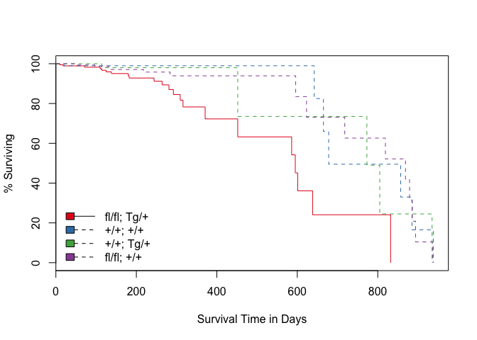

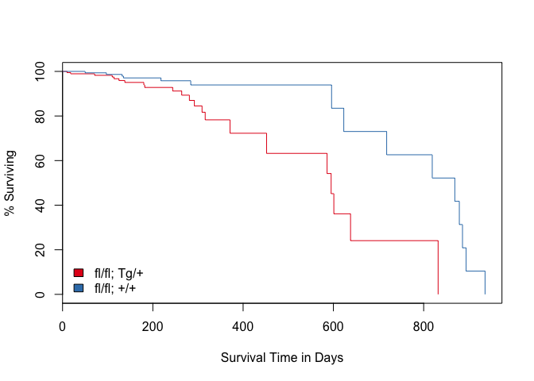

Muscle TSC1 Knockout Summary

|  | Total Animals | Natural Deaths |
| --- | --- | --- |
| Genotype=fl/fl; Tg/+ | 188 | 22 |
| Genotype=+/+; +/+ | 125 | 7 |
| Genotype=+/+; Tg/+ | 104 | 5 |
| Genotype=fl/fl; +/+ | 208 | 15 |

## Combining the Control Mice

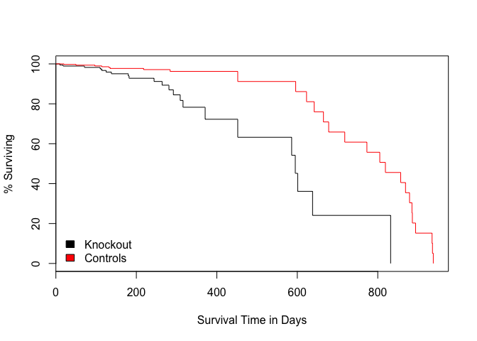

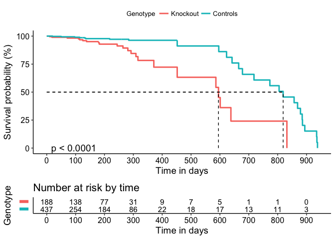

The chi-squared test for comparing the two genotypes is significant, with a p-value of 4.703× 10<sup>-6</sup>. The results of these tests are in the table below. The effects of each genotype, relative to the knockout strains are in the table below. These results are presented graphically in the figure below. This means that the knockout mice are 4.171 times more likely to die at any given time.

## Testing Model Assumptions

|  | rho | chisq | p |
| --- | --- | --- | --- |
| KnockoutTRUE | 0.023 | 0.025 | 0.875 |

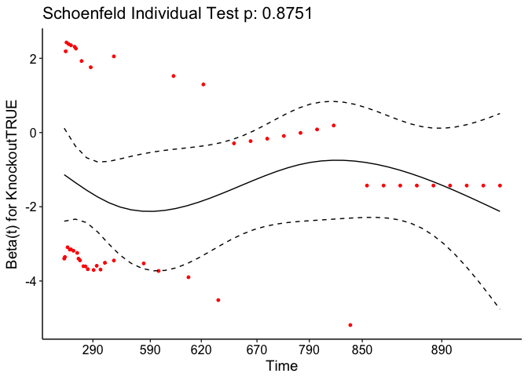

Schoenfeld residuals plotted vs time to test the proportional hazard assumption

We checked for correlation between scaled Schoenfeld residuals with time, and found no violation of the proportional hazard assumption (p = 0.875).

## Influential Observations

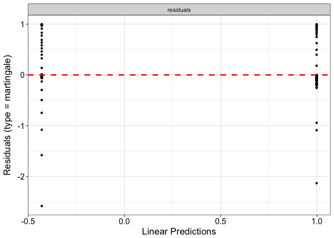

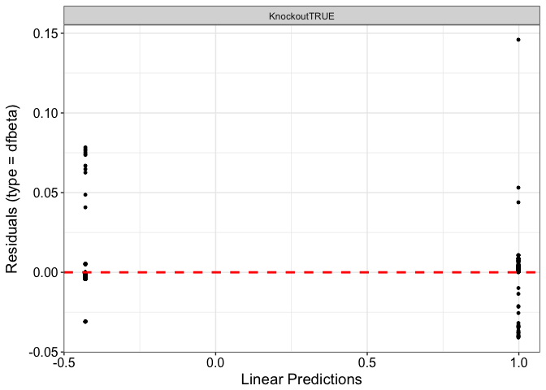

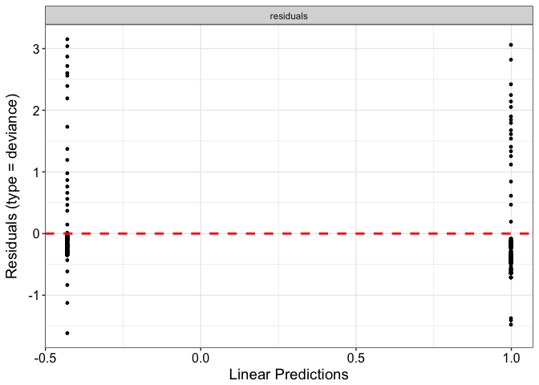

Muscle TSC1 Knockout Tests controls combined

|  | test | df | pvalue |
| --- | --- | --- | --- |
| Likelihood ratio test | 18 | 1 | 0.0000219 |
| Wald test | 18 | 1 | 0.0000202 |
| Score (logrank) test | 21 | 1 | 0.0000047 |

Muscle TSC1 Knockout Coefficients, relative to Knockout, controls combined

|  | beta | se | 2.5 % | 97.5 % | p |
| --- | --- | --- | --- | --- | --- |
| KnockoutTRUE | -1.43 | 0.24 | -2.08 | -0.771 | 0.0000202 |